# Opening the Black Box - Determinants of Tax Morale in Africa

Wiebke Weiger & Jasmin Cantzler

13 November 2015

# 1 Introduction

A country’s ability to efficiently mobilize its national resources is a topic that has recently been gaining traction in the discussion surrounding development. Since the Monterrey Consensus was adopted in 2002, in which countries recognized the importance of raising domestic revenues, development aid has been increasingly shifting from direct financial assistance to improving tax system and national resource management. This shift in strategy was officially stated in 2008, in the Doha Declaration on Financing for Development, which pledged to enhance national tax revenues; one of the recognized strategies pledged to achieve this was combating tax evasion.

High levels of tax evasion lead to a misallocation of resources and hinder the ability of the government to invest in the provision of public goods. Therefore, understanding the rationale behind tax evaders becomes essential to national development and state building. Traditionally, the standard way to explain tax compliance has been the economics-of-crime approach, which assumes a rational taxpayer maximizing his or her utility by balancing the risk of detection and punishment with the benefit of tax evasion. Today, this approach is increasingly regarded as too narrow to fully explain tax compliance, and many argue for the need to include social factors, which are said to explain why people conform to paying taxes even in the absence of strong deterrence mechanisms. These social factors constitute and influence the individual’s “intrinsic motivation to pay taxes”, hereafter referred to as tax morale, by increasing moral costs of tax evasion and thus increasing tax compliance.

# 2 Method

## 2.1 Data Selection and Operationalization

As outlined in Assignment 1, we make use of the Afrobarometer Surveys to investigate the determinants of tax morale in African countries. We merged the survey results from Round 3, 4 and 5, resulting in a data set that spans the years 2005-2006, 2008-2010 and 2011-2013. For a step-by-step protocol please consult this [R-file](https://github.com/jasmincantzler/TaxMorale/blob/master/Assignment%203/PreparatoryWork/merging_data.R).

## 2.2 Descriptive Statistics of Our Data

| Country | meanage | meantaxmorale |
| --- | --- | --- |
| Algeria | 38.45598 | 2.351005 |
| Benin | 37.09086 | 2.351005 |
| Botswana | 38.86013 | 2.351005 |
| Burkina Faso | 37.16331 | 2.351005 |
| Burundi | 37.18000 | 2.351005 |
| Cameroon | 33.54746 | 2.351005 |
| Cap Verde | 38.08714 | 2.351005 |
| Cote dIvoire | 35.57383 | 2.351005 |
| Egypt | 39.05892 | 2.351005 |
| Ghana | 38.37247 | 2.351005 |
| Guinea | 39.57465 | 2.351005 |
| Kenya | 35.64767 | 2.351005 |
| Lesotho | 42.11250 | 2.351005 |
| Liberia | 36.10462 | 2.351005 |
| Madagascar | 38.76808 | 2.351005 |
| Malawi | 35.32700 | 2.351005 |
| Mali | 40.21890 | 2.351005 |
| Mauritius | 43.63917 | 2.351005 |
| Morocco | 36.11204 | 2.351005 |
| Mozambique | 33.10077 | 2.351005 |
| Namibia | 35.10292 | 2.351005 |
| Niger | 38.84448 | 2.351005 |
| Nigeria | 31.94566 | 2.351005 |
| Senegal | 38.39282 | 2.351005 |
| Sierra Leone | 36.15267 | 2.351005 |
| South Africa | 38.79433 | 2.351005 |
| Sudan | 33.93086 | 2.351005 |
| Swaziland | 38.39181 | 2.351005 |
| Tanzania | 37.84155 | 2.351005 |
| Togo | 34.70519 | 2.351005 |
| Tunisia | 42.29764 | 2.351005 |
| Uganda | 33.81181 | 2.351005 |
| Zambia | 34.37360 | 2.351005 |
| Zimbabwe | 37.67819 | 2.351005 |

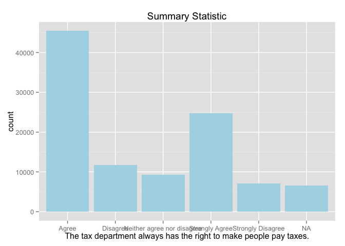

## 2.3 Inferential Statistics

A regression analysis is used to investigate the determinants of tax morale in African countries. Our dependent variable[^1] asks the participants to agree or disagree with the statement “The tax department always has the right to make people pay taxes.” The variable is measured from “Strongly Disagree”, “Disagree”, “Neither Agree or Disagree”, “Agree”, “Strongly Agree”. Since we believe that the “distances” between these five points are not equal, an OLS regression in this case is problematic because the assumptions of OLS are violated when used with a non-interval outcome variable. Instead, we opted for an ordinal logistic regression.

In order to use an ordinal logistic regression the following four assumptions need to hold:

1. The dependent variable is measured at the ordinal level.
2. One or more independent variables that are continuous, ordinal, or categorical
3. There is no multicollinearity
4. Ordinal odds

As indicated above, the first assumption holds true; our tax morale variable is measured at the ordinal level. The second assumption also holds true; all of our independent variables, are continuous, ordinal or categorical. To test for multicollinearity, we applied the variance inflation factor; the result are shown in the table below. Since all numbers exept year are very close to 1, we can assert that there is no multicollinearity.

| Variables | VIF |
| --- | --- |
| as.numeric.mydata.Country. | 1.027688 |
| as.numeric.mydata.Year. | 1.999986 |
| as.numeric.mydata.TrustPresident. | 1.003777 |
| as.numeric.mydata.CorruptionTax. | 1.006615 |
| as.numeric.mydata.SelfEmployedTax. | 1.025368 |
| as.numeric.mydata.Religion. | 1.007205 |
| as.numeric.mydata.Gender. | 1.006259 |
| as.numeric.mydata.EconomicSituation. | 1.003679 |

|  | as.numeric.mydata.Country. | as.numeric.mydata.Year. | as.numeric.mydata.TrustPresident. | as.numeric.mydata.CorruptionTax. | as.numeric.mydata.SelfEmployedTax. | as.numeric.mydata.Religion. | as.numeric.mydata.Gender. | as.numeric.mydata.EconomicSituation. |
| --- | --- | --- | --- | --- | --- | --- | --- | --- |
| as.numeric.mydata.Country. | 1.00 | NA | 0.03 | 0.01 | -0.15 | -0.07 | 0.00 | 0.00 |
| as.numeric.mydata.Year. | NA | 1 | NA | NA | NA | NA | NA | NA |
| as.numeric.mydata.TrustPresident. | 0.03 | NA | 1.00 | -0.07 | -0.01 | 0.01 | 0.00 | 0.00 |
| as.numeric.mydata.CorruptionTax. | 0.01 | NA | -0.07 | 1.00 | 0.03 | 0.00 | -0.01 | -0.05 |
| as.numeric.mydata.SelfEmployedTax. | -0.15 | NA | -0.01 | 0.03 | 1.00 | -0.01 | 0.05 | -0.01 |
| as.numeric.mydata.Religion. | -0.07 | NA | 0.01 | 0.00 | -0.01 | 1.00 | 0.04 | -0.03 |
| as.numeric.mydata.Gender. | 0.00 | NA | 0.00 | -0.01 | 0.05 | 0.04 | 1.00 | -0.01 |
| as.numeric.mydata.EconomicSituation. | 0.00 | NA | 0.00 | -0.05 | -0.01 | -0.03 | -0.01 | 1.00 |

# 3 Discussion & Open Questions

@Wiebke - please have a look - only collecting my doubts here so I don’t forget. 1. Since many of our dependent variables are also nominal we are still investigating whether there are more suitable regression models applicable than ordinal logistic regression. After all, at this point we are treating the dependent variables as numerical. Academic opinions seem strongly divided whether it is okay or highly problematic - what would be your take on this? 2. Maybe there is a way to group our corruption variables together per respondent? Or not advisable

[^1]: For Round 3 (Codebook 2005) it is variable Q52D, for Round 4 (Codebook 2008) it is Q44C, and for Round 5 (2015) it is Q48C.